Skip to main content

# PacDev

- Show All Code
- Hide All Code
- View Source

Housing Price Regression Analysis

Author

Jamison Orton

Published

November 6, 2026

## Q1. Simple Linear Regression

### Initial Model

The first model examines the relationship between home price and square footage.

**Show R code**

```r
simple_lm <- lm(price ~ sqft, data = pacdev)

summary(simple_lm)
```

```
Call:
lm(formula = price ~ sqft, data = pacdev)

Residuals:
    Min      1Q  Median      3Q     Max
-622948 -151283   -1650  138951  804553

Coefficients:
             Estimate Std. Error t value            Pr(>|t|)
(Intercept) 40623.019  15862.454   2.561              0.0105 *
sqft          269.345      7.742  34.791 <0.0000000000000002 ***
---
Signif. codes:  0 '***' 0.001 '**' 0.01 '*' 0.05 '.' 0.1 ' ' 1

Residual standard error: 210300 on 4989 degrees of freedom
Multiple R-squared:  0.1953,    Adjusted R-squared:  0.1951
F-statistic:  1210 on 1 and 4989 DF,  p-value: < 0.00000000000000022
```

**Interpretation**

**Intercept ($40,623.02):** The intercept represents the predicted price of a home with 0 square feet. However, this is not practically meaningful because a home cannot realistically have 0 square feet.

**Square Footage ($269.35):** For every additional square foot, the predicted price of a home increases by approximately $269.35, on average.

### Centering Square Footage

Centering square footage makes the intercept more meaningful by changing the reference point to the average home size.

**Show R code**

```r
simple_fitted <- lm(
  price ~ scale(sqft, scale = FALSE),
  data = pacdev
)

summary(simple_fitted)
```

```
Call:
lm(formula = price ~ scale(sqft, scale = FALSE), data = pacdev)

Residuals:
    Min      1Q  Median      3Q     Max
-622948 -151283   -1650  138951  804553

Coefficients:
                             Estimate Std. Error t value            Pr(>|t|)
(Intercept)                582698.728   2976.382  195.77 <0.0000000000000002
scale(sqft, scale = FALSE)    269.345      7.742   34.79 <0.0000000000000002

(Intercept)                ***
scale(sqft, scale = FALSE) ***
---
Signif. codes:  0 '***' 0.001 '**' 0.01 '*' 0.05 '.' 0.1 ' ' 1

Residual standard error: 210300 on 4989 degrees of freedom
Multiple R-squared:  0.1953,    Adjusted R-squared:  0.1951
F-statistic:  1210 on 1 and 4989 DF,  p-value: < 0.00000000000000022
```

**Interpretation**

The intercept changes because centering shifts the reference point from 0 square feet to the average square footage of homes in the dataset.

Before centering, the intercept represented the predicted price of a home with 0 square feet. After centering, the intercept represents the predicted price of a home with average square footage, which is much more meaningful.

The square footage coefficient and the model’s predictions remain unchanged.

## Q2. Multiple Linear Regression

This model includes city, square footage, bedrooms, and bathrooms as predictors of home price. Numeric predictors are centered, and Long Beach serves as the reference city.

**Show R code**

```r
# Set the reference city
pacdev$city <- relevel(
  factor(pacdev$city),
  ref = "Long Beach"
)

# Center numeric predictors
pacdev_centered <- pacdev %>%
  mutate(
    across(
      all_of(c("sqft", "bed", "bath")),
      ~ as.numeric(scale(.x, scale = FALSE))
    )
  )

# Fit the multiple regression
multiple_fitted <- lm(
  price ~ city + sqft + bed + bath,
  data = pacdev_centered
)

summary(multiple_fitted)
```

```
Call:
lm(formula = price ~ city + sqft + bed + bath, data = pacdev_centered)

Residuals:
    Min      1Q  Median      3Q     Max
-546425 -138158   -2262  124719  845241

Coefficients:
                   Estimate Std. Error t value            Pr(>|t|)
(Intercept)      513686.845   3887.942 132.123 <0.0000000000000002 ***
citySanta Monica 189818.758   6759.691  28.081 <0.0000000000000002 ***
cityWestwood      88101.333   6798.754  12.958 <0.0000000000000002 ***
sqft                272.038      7.516  36.193 <0.0000000000000002 ***
bed                -524.490   8418.596  -0.062               0.950
bath              -2471.708   9440.014  -0.262               0.793
---
Signif. codes:  0 '***' 0.001 '**' 0.01 '*' 0.05 '.' 0.1 ' ' 1

Residual standard error: 195100 on 4985 degrees of freedom
Multiple R-squared:  0.3074,    Adjusted R-squared:  0.3067
F-statistic: 442.6 on 5 and 4985 DF,  p-value: < 0.00000000000000022
```

### Coefficient Interpretations

**Intercept ($513,686.85):** The predicted price of a home in Long Beach with average square footage, average number of bedrooms, and average number of bathrooms is $513,686.85.

**Santa Monica ($189,818.76):** Homes in Santa Monica are predicted to cost $189,818.76 more than comparable homes in Long Beach, holding square footage, bedrooms, and bathrooms constant.

**Westwood ($88,101.33):** Homes in Westwood are predicted to cost $88,101.33 more than comparable homes in Long Beach, holding square footage, bedrooms, and bathrooms constant.

**Square Footage ($272.04):** For every additional square foot, the predicted home price increases by $272.04, on average, holding city, bedrooms, and bathrooms constant.

**Bedrooms (-$524.49):** For every additional bedroom, the predicted home price decreases by $524.49, on average, holding square footage, bathrooms, and city constant. However, this coefficient is not statistically significant (p = 0.950).

**Bathrooms (-$2,471.71):** For every additional bathroom, the predicted home price decreases by $2,471.71, on average, holding square footage, bedrooms, and city constant. However, this coefficient is not statistically significant (p = 0.793).

## Q3. Interaction Effects

### Interaction Model

This model examines whether the relationship between square footage and home price differs by city.

**Show R code**

```r
interaction_fitted <- lm(
  price ~ city * sqft + bed + bath,
  data = pacdev_centered
)

summary(interaction_fitted)
```

```
Call:
lm(formula = price ~ city * sqft + bed + bath, data = pacdev_centered)

Residuals:
    Min      1Q  Median      3Q     Max
-543099 -138790   -3007  126348  861025

Coefficients:
                       Estimate Std. Error t value             Pr(>|t|)
(Intercept)           513735.00    3878.45 132.459 < 0.0000000000000002 ***
citySanta Monica      189480.25    6743.50  28.098 < 0.0000000000000002 ***
cityWestwood           88114.56    6783.00  12.991 < 0.0000000000000002 ***
sqft                     241.52      10.14  23.812 < 0.0000000000000002 ***
bed                     -338.11    8401.82  -0.040               0.9679
bath                   -2468.87    9419.85  -0.262               0.7933
citySanta Monica:sqft     89.63      17.49   5.124          0.000000311 ***
cityWestwood:sqft         36.65      18.05   2.030               0.0424 *
---
Signif. codes:  0 '***' 0.001 '**' 0.01 '*' 0.05 '.' 0.1 ' ' 1

Residual standard error: 194700 on 4983 degrees of freedom
Multiple R-squared:  0.3111,    Adjusted R-squared:  0.3101
F-statistic: 321.5 on 7 and 4983 DF,  p-value: < 0.00000000000000022
```

### Visualizing the Interaction

The following visualization compares the predicted relationship between square footage and home price across the three cities, holding bedrooms and bathrooms at their average values.

**Show R code**

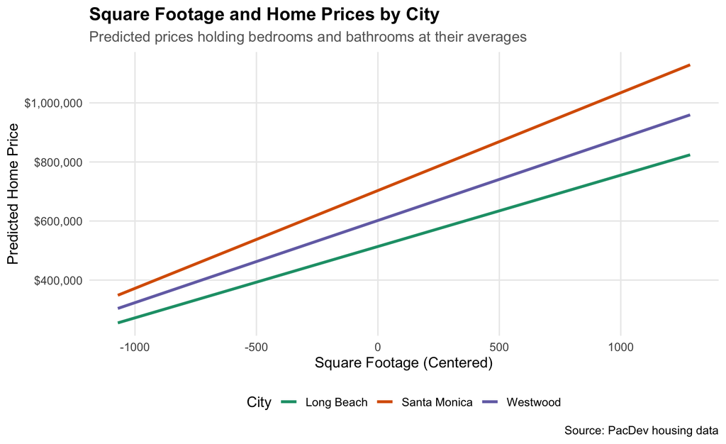

```r
# Create a prediction grid
prediction_grid <- expand.grid(
  sqft = seq(
    min(pacdev_centered$sqft),
    max(pacdev_centered$sqft),
    length.out = 100
  ),
  city = levels(pacdev_centered$city),
  bed = 0,
  bath = 0
)

# Predict prices
prediction_grid$predicted_price <- predict(
  interaction_fitted,
  newdata = prediction_grid
)

# Plot interaction
ggplot(
  prediction_grid,
  aes(
    x = sqft,
    y = predicted_price,
    color = city
  )
) +
  geom_line(linewidth = 1.2) +
  scale_y_continuous(
    labels = scales::label_dollar()
  ) +
  scale_color_brewer(palette = "Dark2") +
  labs(
    title = "Square Footage and Home Prices by City",
    subtitle = "Predicted prices holding bedrooms and bathrooms at their averages",
    x = "Square Footage (Centered)",
    y = "Predicted Home Price",
    color = "City",
    caption = "Source: PacDev housing data"
  ) +
  theme_minimal(base_size = 13) +
  theme(
    plot.title = element_text(face = "bold", size = 16),
    plot.subtitle = element_text(color = "gray40"),
    legend.position = "bottom",
    panel.grid.minor = element_blank()
  )
```

### Interpreting the Interactions

**Santa Monica × Sqft ($89.63):** For every additional square foot, the predicted home price increases by $89.63 more in Santa Monica than in Long Beach, holding bedrooms and bathrooms constant. This interaction is statistically significant (p < 0.001).

**Westwood × Sqft ($36.65):** For every additional square foot, the predicted home price increases by $36.65 more in Westwood than in Long Beach, holding bedrooms and bathrooms constant. This interaction is also statistically significant (p = 0.0424).

### Comparing Price per Square Foot

| City | Estimated Increase per Additional Sqft |
| --- | --- |
| Long Beach | $241.52 |
| Santa Monica | $331.15 |
| Westwood | $278.17 |

The estimated effect of square footage is strongest in Santa Monica, followed by Westwood and Long Beach.

## Q4. Model Diagnostics

### Residual Analysis

A residual plot helps evaluate whether the interaction model adequately captures the relationship between the predictors and home prices.

**Show R code**

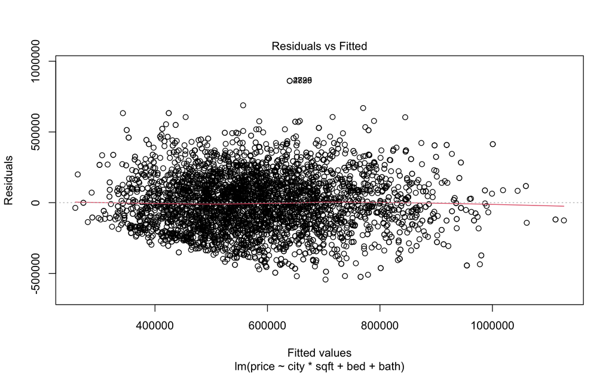

```r
plot(interaction_fitted, which = 1)
```

### Model Fit Assessment

The residual plot shows that most residuals are scattered around zero without a strong pattern, suggesting that the linear model is reasonable.

However, there is some uneven spread in the residuals and a few outliers, indicating that the model does not predict all home prices equally well.

The R-squared value of 0.3111 means the model only explains about 31% of the variation in home prices.

Overall, the model is somewhat useful, but it is not a particularly strong predictor of home prices.

## Q5. Business Recommendation

### Recommended Strategy

Andrew should recommend prioritizing larger homes in **Santa Monica** because additional square footage is associated with the greatest increase in home value there.

### Supporting Evidence

| City | Price Increase per Sqft |
| --- | --- |
| Santa Monica | $331.15 |
| Westwood | $278.17 |
| Long Beach | $241.52 |

Santa Monica homes also have a predicted price premium of approximately **$189,480** over comparable Long Beach homes at average square footage.

This suggests that investing in larger properties in Santa Monica could generate higher selling prices.

### Limitations and Considerations

The interaction model explains only **31.11% of the variation in home prices**. Therefore, higher predicted selling prices do not necessarily mean higher investment returns.

Before making investment decisions, Andrew should also consider purchase costs, renovation expenses, and other property characteristics.

### Final Recommendation

Prioritize evaluating larger properties in Santa Monica for potential investment, but compare expected selling prices against acquisition and improvement costs before committing capital.